# Relatório de dados

Observatório de Aves da Mantiqueira

02/09/2024

## Área de estudo

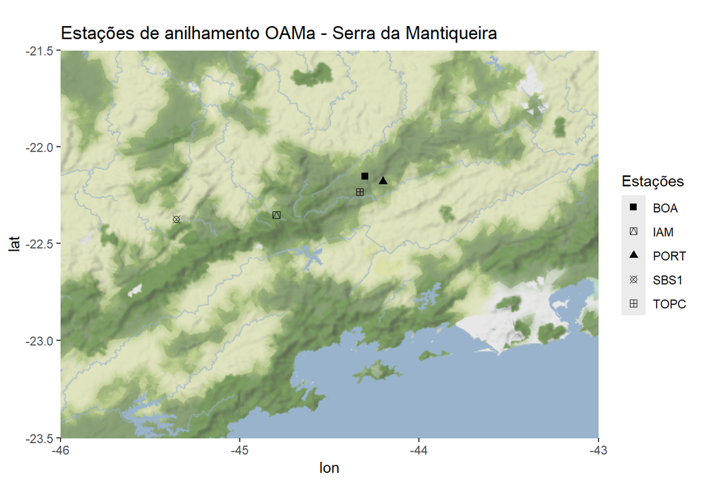

Mapa das estações de anilhamento amostradas pelo monitoramento de avifauna OAMa

## Esforço amostral

Tabela 1. Total de manhãs de anilhamento realizadas em cada estação de anilhamento.

| Estação | Manhãs de Anilhamento |
| --- | --- |
| BOA | 237 |
| IAM | 23 |
| PORT | 19 |
| SBS1 | 2 |
| TOPC | 3 |

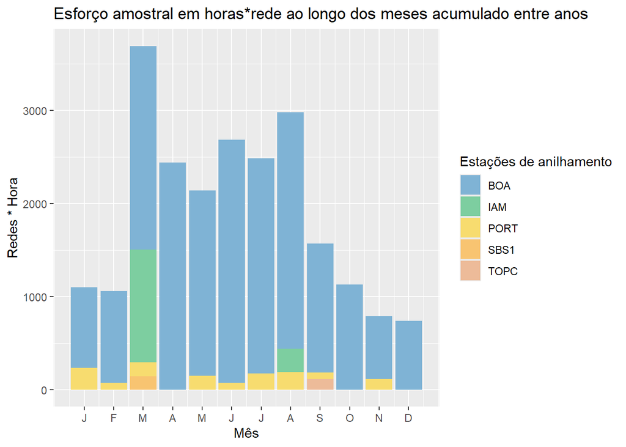

## CAPTURAS

Somamos um total de 6022 capturas em nosso programa de monitoramento até o momento. São 3070 aves anilhadas, e a nossa taxa de recaptura geral entre todas nossas estações de anilhamento foi 0.72, somando mais 2217 capturas á nossa base de dados. Soma-se a essas também as 734 capturas de aves que não foram anilhadas. As informações detalhadas por manhãs de anilhamento estão na tabela 2.

| Estação | Rede*Hora | Espécies | Total de Capturas | Capturas Novas | Recapturas | Sem Anilha | Saudável | Machucadas | Estressadas | Mortes |
| --- | --- | --- | --- | --- | --- | --- | --- | --- | --- | --- |
| BOA | 19849 | 141 | 5169 | 2490 | 2110 | 568 | 4986 | 40 | 92 | 16 |
| IAM | 1463 | 68 | 470 | 354 | 53 | 63 | 446 | 5 | 4 | 0 |
| PORT | 1225 | 51 | 312 | 169 | 51 | 92 | 300 | 0 | 2 | 1 |
| SBS1 | 145 | 20 | 33 | 26 | 0 | 7 | 31 | 0 | 0 | 0 |
| TOPC | 115 | 20 | 38 | 31 | 3 | 4 | 38 | 0 | 0 | 0 |

### Injúrias e Mortes

Nossa taxa de injúrias (aves com pequenos lesões, mas que voaram após primeiros socorros) e de mortalidade até o momento são 0.007 e 0.003, respectivamente.

### Análise de espécies capturadas

Tivemos também 157 espécies registradas em nossos dados de anilhamento até o momento. Nossa estação de anilhamento com maior representação destas espécies foi a BOA, com 141 espécies amostradas no anilhamento até o momento.

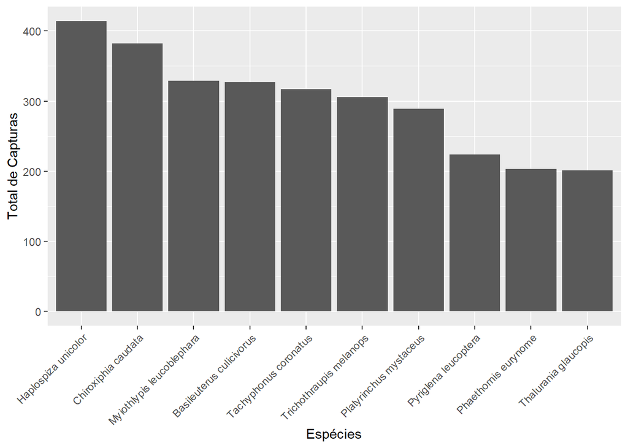

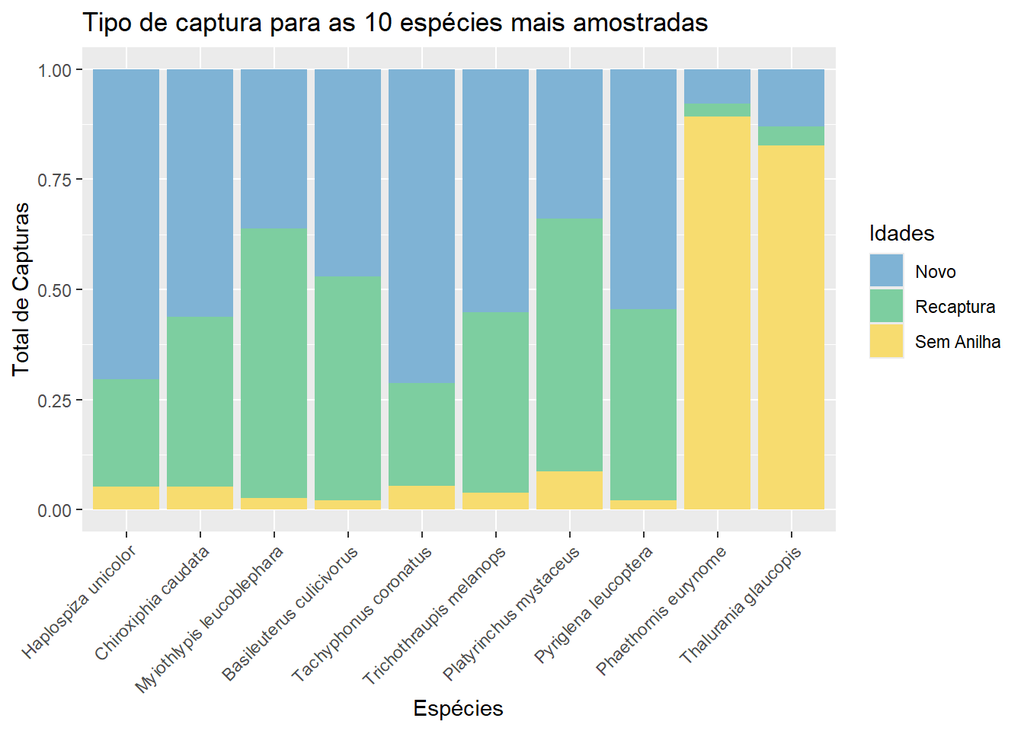

Tabela 3. Número de capturas por espécie e por tipo de captura.

| Espécie | Total de Capturas | Novas | Recapturas | Sem Anilha |
| --- | --- | --- | --- | --- |
| Haplospiza unicolor | 414 | 291 | 101 | 22 |
| Chiroxiphia caudata | 382 | 215 | 147 | 20 |
| Myiothlypis leucoblephara | 329 | 119 | 201 | 9 |
| Basileuterus culicivorus | 327 | 154 | 166 | 7 |
| Tachyphonus coronatus | 316 | 225 | 74 | 17 |
| Trichothraupis melanops | 306 | 169 | 125 | 12 |
| Platyrinchus mystaceus | 289 | 98 | 166 | 25 |
| Pyriglena leucoptera | 224 | 122 | 97 | 5 |
| Phaethornis eurynome | 203 | 16 | 6 | 181 |
| Thalurania glaucopis | 201 | 26 | 9 | 166 |
| Turdus albicollis | 183 | 123 | 53 | 7 |
| Conopophaga lineata | 162 | 89 | 68 | 5 |
| Neopelma chrysolophum | 159 | 97 | 60 | 2 |
| Sittasomus griseicapillus | 140 | 58 | 79 | 3 |
| Ilicura militaris | 136 | 63 | 66 | 7 |
| Xiphorhynchus fuscus | 131 | 36 | 92 | 3 |
| Mionectes rufiventris | 128 | 64 | 63 | 1 |
| Schiffornis virescens | 121 | 26 | 94 | 1 |
| Saltator similis | 110 | 74 | 32 | 4 |
| Synallaxis ruficapilla | 102 | 55 | 42 | 5 |
| Synallaxis cinerascens | 96 | 30 | 63 | 3 |
| Turdus rufiventris | 92 | 68 | 12 | 12 |
| Zonotrichia capensis | 91 | 33 | 53 | 5 |
| Dysithamnus mentalis | 86 | 49 | 34 | 3 |
| Leptopogon amaurocephalus | 82 | 35 | 43 | 4 |
| Thamnophilus caerulescens | 80 | 50 | 29 | 1 |
| Rhopias gularis | 52 | 22 | 30 | 0 |
| Sclerurus scansor | 50 | 18 | 31 | 1 |
| Tangara desmaresti | 46 | 40 | 5 | 1 |
| Tolmomyias sulphurescens | 45 | 29 | 13 | 3 |

[output cut: 127 more lines]

## Fenologia

Apesar de ainda ser jovem, o monitoramento de longo prazo do OAMa já foi capaz de identificar padrões na distribuição temporal de idades, em especiais as relacionadas ao primeiro ciclo de muda das aves, e de atividade reprodutiva e de muda.

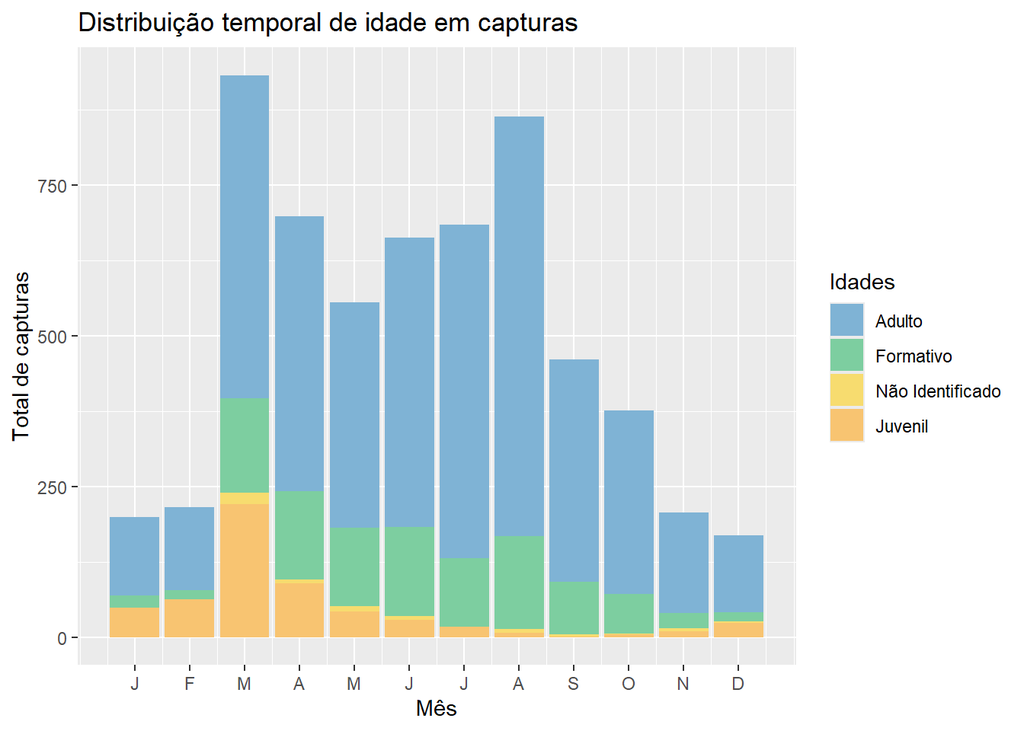

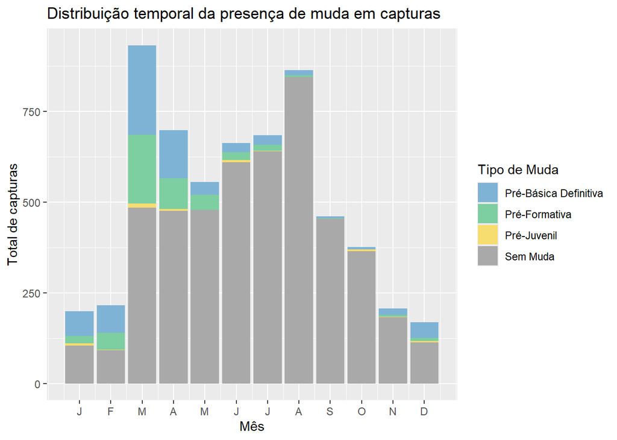

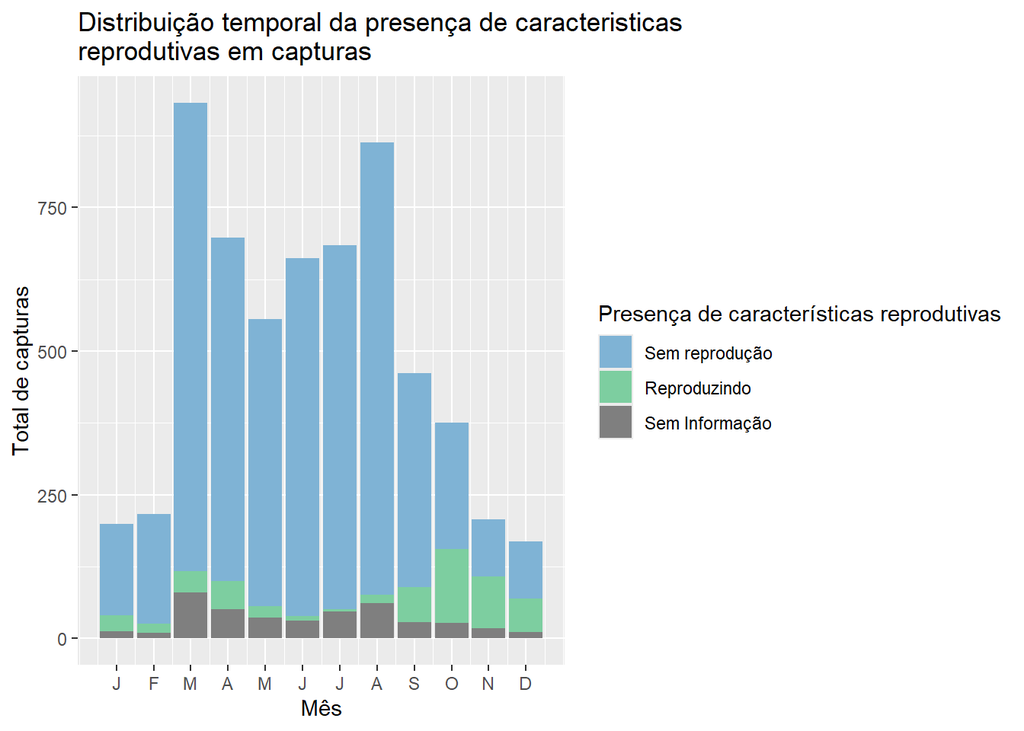